# Introduction to SHARPy

Version: *June 2019*

# Overview

SHARPy (Simulation of High Aspect Ratio Planes in Python is a framework for linear and nonlinear aeroelastic analysis of flexible structures.

It is developed by the Loads Control and Aeroelasticity lab at the Department of Aeronautics. All the code is open source and readily available in GitHub.

**Important links:**

Loads Control and Aeroelasticity lab https://imperial.ac.uk/aeroelastics

Main github repository https://github.com/imperialcollegelondon/sharpy

Documentation(!!!) https://ic-sharpy.readthedocs.io

UVLM solver (C++) https://github.com/imperialcollegelondon/uvlm

Structural solver (Fortran) https://github.com/imperialcollegelondon/xbeam

SHARPy is mainly coded in Python, but the expensive routines, such as aero and structural solvers are coded in faster languages such as C++ and Fortran.

A number of different structures and analysis methods can be run. For example:

## Very flexible aircraft nonlinear aeroelasticity (Alfonso)

The modular design of SHARPy allows to simulate complex aeroelastic cases involving very flexible aircraft. The structural solver supports very complex beam arrangements, while retaining geometrical nonlinearity. The UVLM solver features different wake modelling fidelities while supporting large lifting surface deformations in a native way.

Among the problems studied, a few interesting ones, in no particular order are:

- Catapult take off of a very flexible aircraft analysis [[Paper]](https://arc.aiaa.org/doi/abs/10.2514/6.2019-2038). In this type of simulations, a PID controller was used in order to enforce displacements and velocities in a number of structural nodes (the clamping points). Then, several take off strategies were studied in order to analyse the influence of the structural stiffness in this kind of procedures. This case is a very good example of the type of problems where nonlinear aerolasticity is essential.

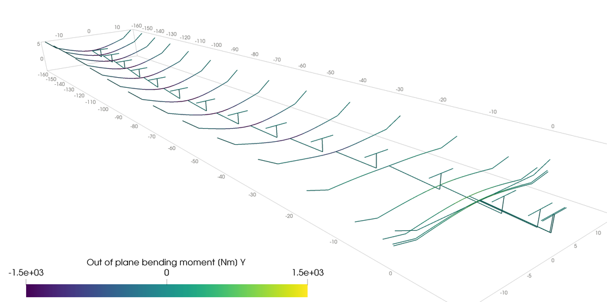

- Flight in full 3D atmospheric boundary layer (to be published). A very flexible aircraft is flown immersed in a turbulent boundary layer obtained from HPC LES simulations. The results are compared against simpler turbulence models such as von Karman and Kaimal. Intermittency and coherence features in the LES field are absent or less remarkable in the synthetic turbulence fields.

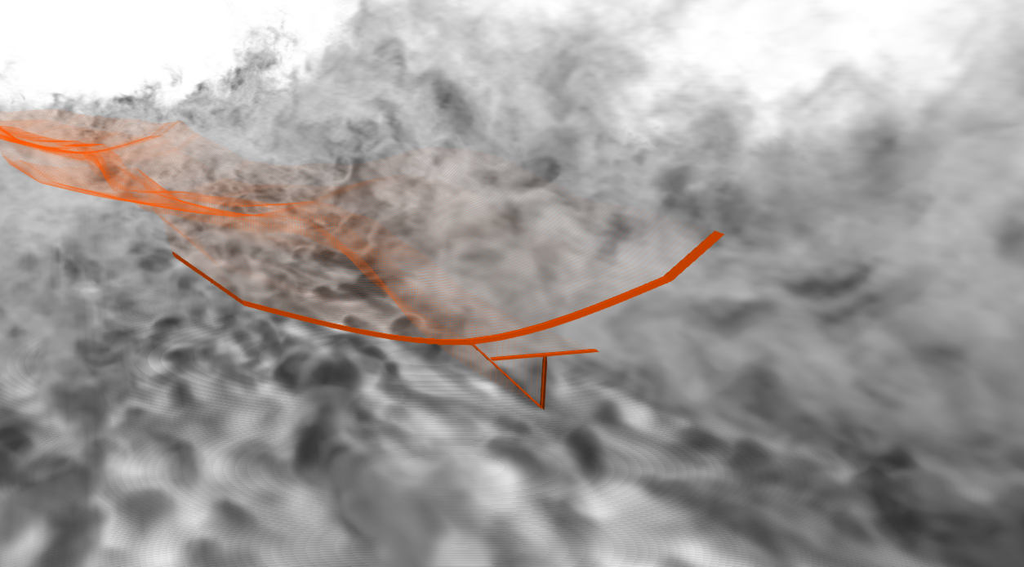

- Lateral gust reponse of a realistic very flexible aircraft. For this problem (to be published), a realistic very flexible aircraft (University of Michigan X-HALE) model has been created in SHARPy and validated against their own aeroelastic solver for static and dynamic cases. A set of vertical and lateral gust responses have been simulated. (Results to be presented at IFASD 2019).

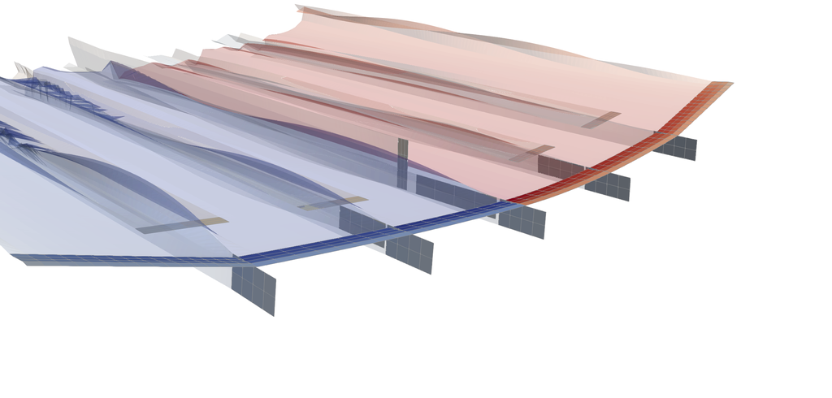

## Wind turbine aeroelasticity (Arturo)

SHARPy is suitable to simulate wind turbine aeroelasticity.

On the structural side, it accounts for material anisotropy which is needed to characterize composite blades and for geometrically non-linear deformations observed in current blades due to the increasing length and flexibility. Both rigid and flexible simulations can be performed and the structural modes can be computed accounting for rotational effects (Campbell diagrams). The rotor-tower interaction is modelled through a multibody approach based on the theory of Lagrange multipliers. Finally, he tower base can be fixed or subjected to prescribed linear and angular velocities.

On the aerodynamic side, the use of potential flow theory allows the characterization of flow unsteadiness at a reasonable computational cost. Specifically, steady and dynamic simulations can be performed. The steady simulations are carried out in a non-inertial frame of reference linked to the rotor under uniform steady wind with the assumption of prescribed helicoidal wake. On the other hand, dynamic simulations can be enriched with a wide variety of incoming winds such as shear and yaw. Moreover, the wake shape can be freely computed under no assumptions accounting for self-induction and wake expansion or can be prescribed to an helicoidal shape for computational efficiency.

PD: aft-loaded airfoils can be included through the definition of the camber line of the blades.

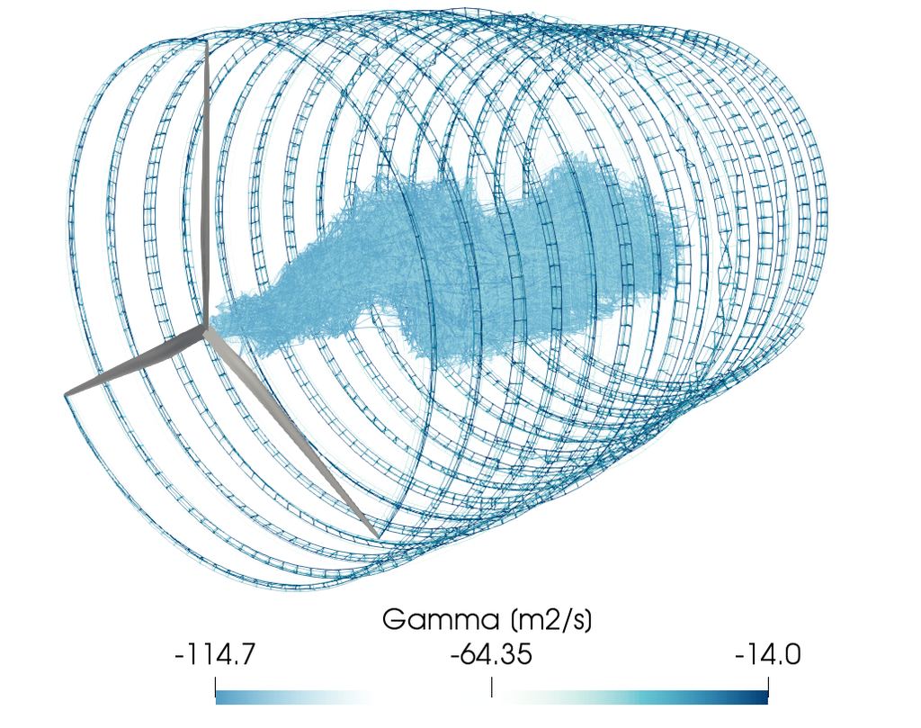

## Model Order Reduction

Numerical models of physical phenomena require fine discretisations to show convergence and agreement with their real counterparts, and, in the case of SHARPy's aeroelastic systems, hundreds of thousands of states are not an uncommon encounter. However, modern hardware or the use of these models for other applications such as controller synthesis may limit their size, and we must turn to model order reduction techniques to achieve lower dimensional representations that can then be used.

SHARPy offers several model order reduction methods to reduce the initially large system to a lower dimension, attending to the user's requirements of numerical efficiency or global error bound.

### Krylov Methods for Model Order Reduction - Moment Matching

Model reduction by moment matching can be seen as approximating a transfer function through a power series expansion about a user defined point in the complex plane. The reduction by projection retains the moments between the full and reduced systems as long as the projection matrices span certain Krylov subspaces dependant on the expansion point and the system's matrices. This can be taken advantage of, in particular for aeroelastic applications where the interest resides in the low frequency behaviour of the system, the ROM can be expanded about these low frequency points discarding accuracy higher up the frequency spectrum.

#### Example 1 - Aerodynamics - Frequency response of a high AR flat plate subject to a sinusoidal gust

The objective is to compare SHARPy's solution of a very high aspect ratio flat plate subject to a sinusoidal gust to the closed form solution obtained by Sears (1944 - Ref). SHARPy's inherent 3D nature makes comparing results to the 2D solution require very high aspect ratio wings with fine discretisations, resulting in very large state space models. In this case, we would like to utilise a Krylov ROM to approximate the low frequency behaviour and perform a frequency response analysis on the reduced system, since it would represent too much computational cost if it were performed on the full system.

The full order model was reduced utilising Krylov methods, in particular the Arnoldi iteration, with an expansion about zero frequency to produce the following result.

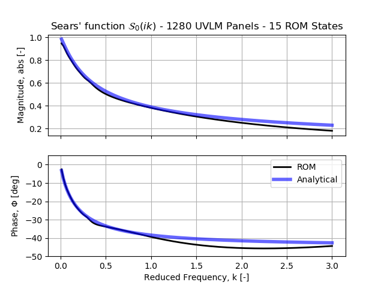

As it can be seen from the image above, the ROM approximates well the low frequency, quasi-steady state and loses accuracy as the frequency is increased, just as intended. Still, perfect matching is never achieved even at the expansion frequency given the 3D nature of the wing compared to the 2D analytical solution.

#### Example 2 - Aeroelastics - Flutter analysis of a Goland wing with modal projection

The Goland wing flutter example is presented next. The aerodynamic surface is finely discretised for the UVLM solution, resulting in not only a large state space but also in large input/output dimensionality. Therefore, to reduce the number of inputs and outputs, the UVLM is projected onto the structural mode shapes, the first four in this particular case. The resulting multi input multi output system (mode shapes -> UVLM -> modal forces) was subsequently reduced using Krylov methods aimed at MIMO systems which use variations of the block Arnoldi iteration. Again, the expansion frequency selected was the zero frequency. As a sample, the transfer function from two inputs to two outputs is shown to illustrate the performance of the reduced model against the full order UVLM.

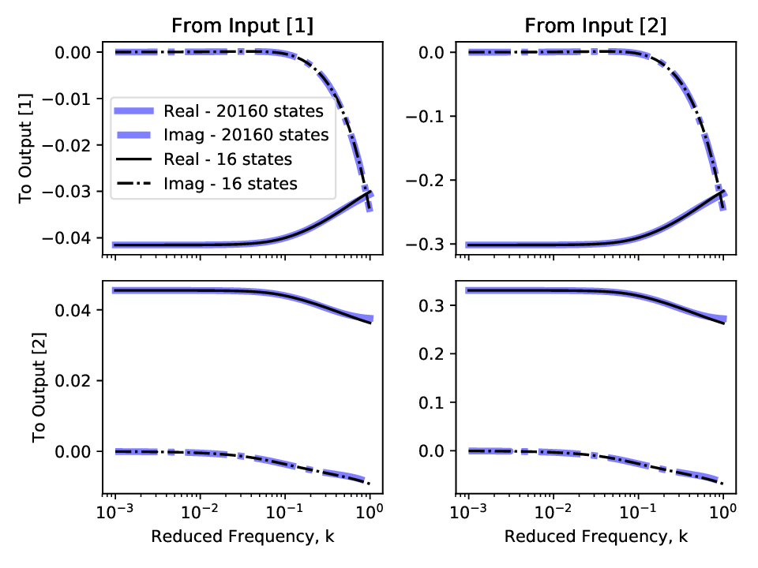

The reduced aerodynamic model projected onto the modal shapes was then coupled to the linearised beam model, and the stability analysed against a change in velocity. Note that the UVLM model and its ROM are actually scaled to be independent on the freestream velocity, hence only one UVLM and ROM need to be computed. The structural model needs to be updated at each test velocity but its a lot less costly in computational terms. The resulting stability of the aeroelastic system is plotted on the Argand diagram below with changing freestream velocity.

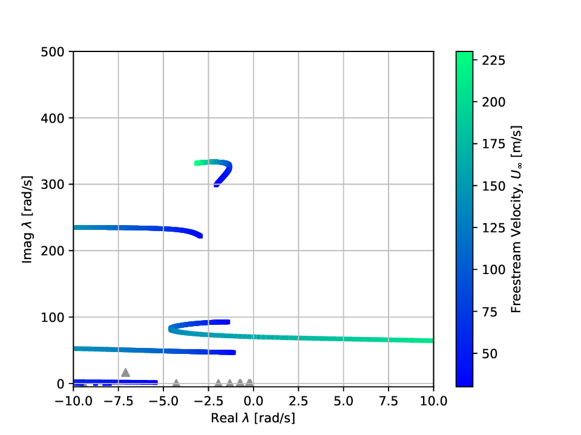

| Flutter speed [m/s] | Frequency [rad/s] |
| --- | --- |
| 164 | 70.27 |

# SHARPy installation

Check https://ic-sharpy.readthedocs.io/en/latest/content/installation.html for an in-depth guide on how to install SHARPy.

This assumes a few things about your computer:

- It is Linux or MacOS (definitely not Windows - if you only have Windows, check VirtualBox and make an Ubuntu or CentOS virtual machine).
- It has an up-to-date compiler (this might not be straightforward, run `g++ --version`. If lower than 5.0, you will need to update it). An up-to-date Intel Compiler for C++ and Fortran is a good option as well.

SHARPy relies on Anaconda https://www.anaconda.com/distribution/ to handle all the python packages. Install the Python 3 version.

You then need to download the code:

1) Create a folder. Here it will be called `code`

```
mkdir code
cd code
```

2) Clone all the necessary repos **and make sure you are in the correct branch -- usually develop**

```
git clone https://github.com/imperialcollegelondon/sharpy --branch=develop
git clone https://github.com/imperialcollegelondon/xbeam --branch=develop
git clone https://github.com/imperialcollegelondon/uvlm --branch=develop
```

3) Create the conda environment and activate it

```
conda env create -f sharpy/utils/environment_linux.yml
```

(or `environment_macos.yml` if on MacOS.

Now activate the conda environment

`conda activate sharpy_env` you are going to have to do this every time to start a new terminal and want to run SHARPy

It sometimes fails in the `pip` stage when installing. If it says something about `distwheel` failed in `mayavi`, activate the environment and run `pip install mayavi` manually.

4) Compile `xbeam` and `uvlm`.

Move to the `xbeam` folder (`cd xbeam`) and run `sh run_make.sh`. Wait until it finishes. Please make sure your anaconda env is active before running this.

Now the same for `uvlm`: `cd ../uvlm` and `sh run_make.sh`.

5) SHARPy is now hopefully ready to go!

Navigate to the `sharpy` folder: `cd ../sharpy` and run:

```
source bin/sharpy_vars.sh
```

This command is important, as it loads the program in the terminal variables.

We can run the tests now:

```
python -m unittest
```

If everything has been installed properly, the tests should pass.

```
----------------------------------------------------------------------
Ran 28 tests in 23.465s

OK
```

**Remember to run every time you start a new terminal:**

```
conda activate sharpy_env
source <path-to-sharpy>/bin/sharpy_vars.sh
```

Tip: edit your `~\.bashrc` (linux) or `\.bash_profile` (MacOS) and add the following:

```
alias load_sharpy="conda activate sharpy_env && source <path-to-sharpy>/bin/sharpy_vars.sh"
# Remember to modify the <path-to-sharpy> gap with your path
```

Then you just need to run in the console `load_sharpy` to load everything in one go.

# Basic cases

## A cantilever beam (Geradin)

This case can be found in `sharpy/tests/xbeam/geradin`, it is part of the test suite.

Basically, it is a 5 metres long cantilevered beam with a mass at the tip. Stiffness properties: $\mathcal{S} = \mathrm{diag}(EI, GA_y, GA_z, GJ, EI_y, EI_z) = \mathrm{diag}(4.8e8, 3.231e8, 3.231e8, 1e6, 9.346e6, 9.346e6)$

There is no distributed mass, only one at the tip. $M = 6e5/9.81$.

The main point about the Geradin beam is that the deflections are past the linear range.

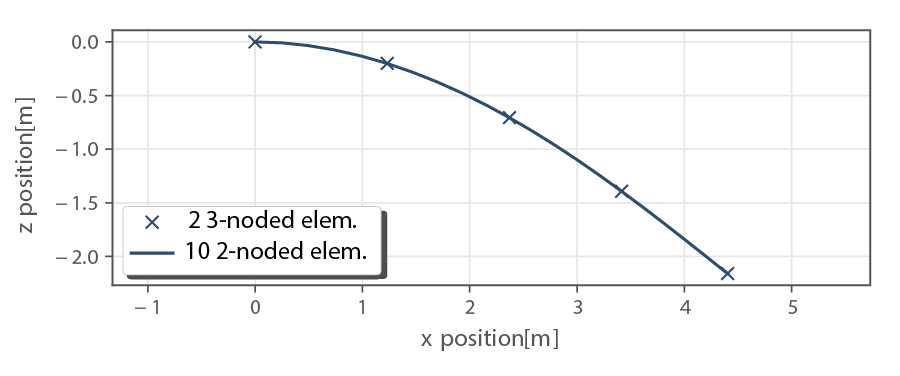

If you open `sharpy/tests/xbeam/geradin/generate_geradin.py`, you are going to see a basic input file for a structural only case.

The last part is the one that is the most important (function `generate_solver_file` from line 134). This is where the solver settings and the overall flow of the program is given.

- **The `flow` variable** controls the solvers and postprocessors that are going to be run in this simulation (and in which order). When you run sharpy with a valid header file, you will see a complete list of available solvers:

```
--------------------------------------------------------------------------------
            ######  ##     ##    ###    ########  ########  ##    ##
           ##    ## ##     ##   ## ##   ##     ## ##     ##  ##  ##
           ##       ##     ##  ##   ##  ##     ## ##     ##   ####
            ######  ######### ##     ## ########  ########     ##
                 ## ##     ## ######### ##   ##   ##           ##
           ##    ## ##     ## ##     ## ##    ##  ##           ##
            ######  ##     ## ##     ## ##     ## ##           ##
--------------------------------------------------------------------------------
Aeroelastics Lab, Aeronautics Department.
    Copyright (c), Imperial College London.
    All rights reserved.
Running SHARPy from /home/ad214/run/code/sharpy/tests/xbeam/geradin
SHARPy being run is in /home/ad214/run/code/sharpy
The branch being run is develop
The version and commit hash are: v0.1-731-g85eb5ab-85eb5ab
The available solvers on this session are:
PreSharpy
AerogridLoader
BeamLoader
Modal
NonLinearDynamic
NonLinearDynamicCoupledStep
NonLinearDynamicPrescribedStep
NonLinearStatic
PIDTrajectoryControl
PrescribedUvlm
StaticCoupled
StaticTrim
StaticUvlm
StepUvlm
Trim
RigidDynamicPrescribedStep
DynamicUVLM
StepLinearUVLM
StaticLinearUvlm
InitializeMultibody
LagrangeMultipliersTrajectoryControl
NonLinearDynamicMultibody
SHWUvlm
StaticCoupledRBM
SteadyHelicoidalWake
DynamicCoupled
AeroForcesCalculator
AerogridPlot
BeamLoads
BeamPlot
Cleanup
SaveData
StallCheck
WriteVariablesTime
PlotFlowField
CreateSnapshot
LiftDistribution
```

For our simple structural simulation, we only need a few blocks: `BeamLoader` for reading the input file and generating the beam data structure, `NonLinearStatic` is the structural solver for *nonlinear*, *static* beams, `BeamPlot` outputs the deformed shape and other quantities to a Paraview file structure (more on this later), and `WriteVariablesTime` outputs the data we want to text files.

- **The `case`** is a name for the simulation so we can identify results.
- **The `route`** is the path to the `.sharpy` file, so that SHARPy can find all the other necessary files.

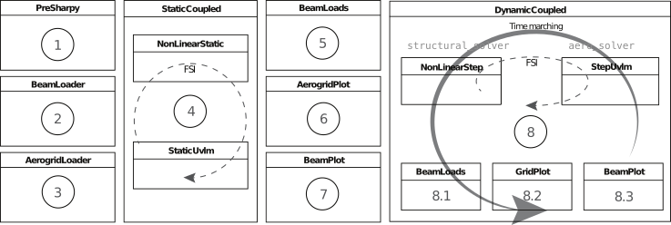

Then, the other parts of the `.sharpy` (or `.sharpy`) file are based on the following structure:

```
[Header_name]
variable1 = 1
variable2 = a
variable3 = [a, a, b]
```

It is important to note that you need a header per every solver indicated in `flow`. If that solver needs no settings, you still need to indicate the header.

There is also a main `[SHARPy]` header that contains the main program settings, such as the `flow` and the `case`. It also has a setting called `write_screen`. It is equal to `off` because this is a test case, and you don't want tons of output. If you modify it to `'on'`, you'll be able to see what's going on on the screen.

### Simple modifications of the case

If we want to (for example), run a stiffer beam, we can do so easily:

Open `generate_geradin.py` and move to line 50 more or less where there are a few lines looking like:

```
ea = ...
ga = ...
#...
ei = ...
```

and modify them to look like:

```
stiffness_multiplier = 10
ea = ... * stiffness_multiplier
ga = ... * stiffness_multiplier
#...
ei = ... * stiffness_multiplier
```

you can also change the name of the case so that the results are not overwritten: In line `6`, `case_name = geradin_stiff`.

Now run again the case. First, generate the files: `python generate_geradin.py`, and then run the case `sharpy geradin_stiff.sharpy`.

You can now have a look at the wing tip deformations for both cases in `output/<case_name>/WriteVariablesTime/struct_pos_node-1.dat`.

# Guide to model definition in SHARPy

This section will take a bit of time and is quite tough to follow, but keep this as a reference.

## Structural data

The `case.fem.h5` file has several components. We go one by one:

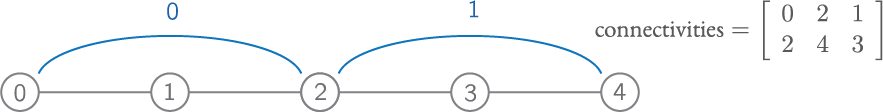

The shape of a stiffness matrix, $\mathrm{S}$ is: $$\mathrm{S} = \begin{bmatrix} EA & & & & & \\ & GA_y & & & & \\ & & GA_z & & & \\ & & & GJ & & \\ & & & & EI_y & \\ & & & & & EI_z \\ \end{bmatrix} $$ with the cross terms added if needed.

- `mass_db` and `elem_mass` follow the same scheme than the stiffness, but the mass matrix is given by: $$\mathrm{M} = \begin{bmatrix} m\mathbf{I} & -\tilde{\xi}_{cg}m \\ \tilde{\xi}_{cg}m & J\\ \end{bmatrix} $$ where $m$ is the distributed mass per unit length [kg/m], $\tilde{\bullet}$ is the skew-symmetric matrix of a vector and $\xi_{cg}$ is the location of the centre of gravity with respect to the elastic axis in **MATERIAL (local) FoR**.

And what is the Material FoR? This is an important point, because all the inputs that move WITH the beam are in material FoR. For example: follower forces, stiffness, mass, lumped masses...

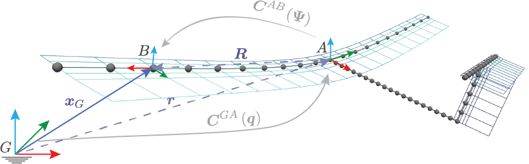

The material frame of reference is noted as $B$. Essentially, the $x$ component is tangent to the beam in the increasing node ordering, $z$ looks up generally and $y$ is oriented such that the FoR is right handed.

In the practice (vertical surfaces, structural twist effects...) it is more complicated than this. The only sure thing about $B$ is that its $x$ direction is tangent to the beam in the increasing node number direction. However, with just this, we have an infinite number of potential reference frames, with $y$ and $z$ being normal to $x$ but rotating around it. The solution is to indicate a `for_delta`, or frame of reference delta vector ($\Delta$).

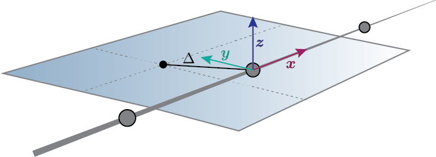

Now we can define unequivocally the material frame of reference. With $x_B$ and $\Delta$ defining a plane, $y_b$ is chosen such that the $z$ component is oriented upwards with respect to the lifting surface.

From this definition comes the only constraint to $\Delta$: it cannot be parallel to $x_B$.

- `frame_fo_reference_delta [num_elem, num_node_elem, 3]` contains the $\Delta$ vector in body-attached ($A$) frame of reference. As a rule of thumb: $$\Delta = \left\{ \begin{matrix} [-1, 0, 0], \quad \text{if right wing} \\ [1, 0, 0], \quad \text{if left wing} \\ [0, 1, 0], \quad \text{if fuselage} \\ [-1, 0, 0], \quad \text{if vertical fin} \\ \end{matrix} \right. $$

These rules of thumb only work if the nodes increase towards the tip of the surfaces (and the tail in the case of the fuselage).

- `structural_twist [num_elem, num_node_elem]` is technically not necessary, as the same effect can be achieved with FoR_delta. **CAUTION** previous versions of SHARPy had structural twist defined differently:

```
structural_twist = np.zeros((num_node, num_node_elem)) # this is wrong now, and will trigger and error in SHARPy, change it!
structural_twist = np.zeros((num_elem, num_node_elem)) # this is right.
```

- `boundary_conditions [num_node]` is an array of integers (`np.zeros((num_node, ), dtype=int)`) and contains all `0` EXCEPT FOR:
  - One node NEEDS to have a `1`, this is the reference node. Usually, the first node has `1` and is located in `[0, 0, 0]`. This makes things much easier.
  - If the node is a tip of a beam (is not attached to 2 elements, but just 1), it needs to have a `-1`.
- `beam_number [num_elem]` is another array of integers. Usually you don't need to modify its value. Leave it at 0.
- `app_forces [num_elem, 6]` contains the applied forces `app_forces[:, 0:3]` and moments `app_forces[:, 3:6]` in a given node. Important points: the forces are given in Material FoR (check above). That means that in a symmetrical model, a thrust force oriented upstream would have the shape $[0, T, 0, 0, 0, 0]$ in the right wing, while the left would be $[0, -T, 0, 0, 0, 0]$. Likewise, a torsional moment for twisting the wing leading edge up would be $[0, 0, 0, M, 0, 0]$ for the right, and $[0, 0, 0, -M, 0, 0]$ for the left. But careful, because an out-of-plane bending moment (wing tip up) has the same sign (think about it).
- `lumped_mass [:]` is an array with as many masses as needed (in kg this time). Their order is important, as more information is required to implement them in a model.
- `lumped_mass_nodes [:]` is an array of integers. It contains the index of the nodes related to the masses given in `lumped_mass` in order.
- `lumped_mass_inertia [:, 3, 3]` is an array of 3x3 inertial tensors. The relationship is set by the ordering as well.
- `lumped_mass_position [:, 3]` is the relative position of the lumped mass wrt the node (given in `lumped_masss_nodes`) coordinates. **ATTENTION:** the lumped mass is solidly attached to the node, and thus, its position is given in Material FoR.

## Aerodynamic data

All the aero data is contained in `case.aero.h5`.

It is important to know that the input for aero is usually based on elements (and inside the elements, their nodes). This causes sometimes an overlap in information, as some nodes are shared by two adjacent elements (like in the connectivities graph in the previous section). The easier way of dealing with this is to make sure the data is consistent, so that the properties of the last node of the first element are the same than the first node of the second element.

Item by item:

- In the `aero.h5` file, there is a Group called `airfoils`. The airfoils are stored in this group (which acts as a folder) as a two-column matrix with $x/c$ and $y/c$ in each column. They are named `'0', '1'`, and so on.
- `chords [num_elem, num_node_elem]` is an array with the chords of every airfoil given in an element/node basis.
- `twist [num_elem, num_node_elem]` has the twist angle in radians. It is implemented as a rotation around the local $x$ axis.
- `sweep [num_elem, num_node_elem]` same here, just a rotation around $z$.
- `airfoil_distribution_input [num_elem, num_node_elem]` contains the indices of the airfoils that you put previously in `airfoils`
- `surface_distribution_input [num_elem]` is an integer array. It contains the index of the surface the element belongs to. Surfaces need to be continuous, so please note that if your beam numbering is not continuous, you need to make a surface per continuous section.
- `surface_m [num_surfaces]` is an integer array with the number of chordwise panels for every surface.
- `m_distribution [string]` is a string with the chordwise panel distribution. In almost all cases, leave it at `uniform`.
- `aero_node_input [num_node]` is a boolean (True/False) array that indicates if that node has a lifting surface attached to it.
- `elastic_axis [num_elem, num_node_elem]` indicates the elastic axis location with respect to the leading edge as a fraction of the chord of that rib. Note that the elastic axis is already determined, as the beam is fixed now, so this settings controls the location of the lifting surface wrt the beam.
- `control_surface [num_elem, num_node_elem]` is an integer array containing `-1` if that section has no control surface associated to it, and `0, 1, 2 ...` if the section belongs to the control surface `0, 1, 2 ...` respectively.
- `control_surface_type [num_control_surface]` contains `0` if the control surface deflection is static, and `1` is it is dynamic (if you need to run dynamic control surfaces, come see me).
- `control_surface_chord [num_control_surface]` is an INTEGER array with the number of panels belonging to the control surface. For example, if $M = 4$ and you want your control surface to be $0.25c$, you need to put `1`.
- `control_surface_hinge_coord [num_control_surface]` only necessary for lifting surfaces that are deflected as a whole, like some horizontal tails in some aircraft. Leave it at 0 if you are not modelling this. If you are, come see me.

## Common solver settings

The solver settings are covered almost entirely in the documentation (again: https://ic-sharpy.readthedocs.io). I'm going to explain in more detail the important ones. The defaults settings are generally good enough for a majority of cases.

### BeamLoader

BeamLoader reads the solver.txt and the fem.h5 files and generates the `beam` data structure. Its settings are simple:

- `unsteady` leave it on
- `orientation` is what is used to set the attitude angles. It is given as a quaternion (CAREFUL: a null rotation in quaternions is $[1, 0, 0, 0]$). You can give it in Euler angles as: `'orientation' = algebra.euler2quat(np.array([roll, alpha, beta]))`.

### AerogridLoader

- `mstar` number of chordwise panels for the wake. A good value is $$M^* = \frac{L_{\mathrm{wake}}}{\Delta t u_\infty}$$, which means that the wake panels are the same size as the main wing ones.
- `freestream_dir` is a different approach to modifying the attitude angles. I'd leave alone unless you really need it.

### NonLinearStatic

The static beam solver settings. Important ones:

- `max_iterations` maximum number of iterations for the structural solver. These are not the same as the ones in `DynamicCoupled`.
- `num_load_steps` if > 1, the applied forces and gravity are applied progressively in several steps in order to avoid numerical divergence. Leave it at 1 unless you have problems with convergence of static cases.
- `delta_curved` leave it at $1e-1$.
- `min_delta` this one is more tricky. Usually $1e-6$ works well for flexible structures. If you are running more stiff stuff, you might need to lower it even more. Don't go under $1e-11$. If you don't know, start at $1e-6$, note the wing tip deflection and lower it even more. A too low value will cause the beam solver to reach `max_iterations` without convergence. When this happens, note the residual value and set something larger than that.
- `gravity_on` `on` if gravity, `off` if not.
- `gravity` $9.81$ if you are on Earth. Setting it to 0 is the same as `gravity_on` = `off`, but the latter is quicker.

### StaticUvlm

- `horseshoe` if this is `on`, `mstar` (in AerogridLoader) has to be 1. It controls the wake modelling. Usual wakes with `mstar > 1` are discretised and are of finite length. The horsehoe modelling is derived from the analytical expansion of an discretised wake of infinite length. ATTENTION: use only in static simulations.
- `n_rollup` how many steps are carried out to convect the wake with full free-wake. This usually should be `0`, but if you want a pretty picture, you can use `n_rollup = int(mstar*1.5)`.
- `rollup_dt` if `n_rollup > 0`, set `rollup_dt` to $$ \Delta t_{\mathrm{rollup}} = \frac{c/M}{u_\infty} $$
- 'velocity_field_generator' a few options available here. This paragraph is applicable to every aero solver that has a `velocity_field_generator` setting.
  - `SteadyVelocityField`: quite straightforward. Give a u_inf value in `u_inf` and a direction in `u_inf_direction`.
  - `GustVelocityField`: this one generate gusts in several profiles. The ones you will probably use: `gust_shape: '1-cos'`, or `'continuous_sin'`.
    - `u_inf` and `u_inf_direction` already explained
    - `gust_length`: equvalent to $2H$ in metres.
    - `gust_intensity`: reference (peak) velocity of the gust, in m/s.
    - `offset` x coord. of the first point of the gust with respect to the $[0, 0, 0]$ in inertial.
    - `span`: span of the aircraft (you are probably not going to use this, it is implemented for DARPA gusts).
  - `VelocityFieldGenerator`: a full unsteady 3D field of velocities is input. Ask me if you want to use it.

### StaticCoupled

- `print_info`: set it to `on` in almost all cases.
- `structural_solver` and `aero_solver`: these are strings with the name of the structural and aerodynamic solvers you want to use for the coupled simulation. A solver with that name needs to exist in SHARPy (check the list of available solvers at the start of a simulation).
- `structural_solver_settings` and `aero_solver_settings`: a dictionary (each) that is basically the same you added before if you wanted to run a standalone structural or aero simulation. A code example:

```
settings = dict()
settings['NonLinearStatic'] = {
    'print_info': 'on',
    'max_iterations': 150
    # ...
}
settings['StaticUvlm'] = {
    'print_info': 'on',
    'horseshoe': 'off'
    # ...
}

settings['StaticCoupled'] = {
    'structural_solver': 'NonLinearStatic',
    'structural_solver_settings': settings['NonLinearStatic'],
    'aero_solver': 'StaticUvlm',
    'aero_solver_settings': settings['StaticUvlm'],
    # ...
```

### Static trim

This solver acts like a wrapper of `StaticCoupled`, just like `StaticCoupled` is a wrap for the structural and aero solver. That means that when we initialise the `StaticTrim` solver, we also create a `StaticCoupled`, a `NonlinearStatic` and a `StaticUvlm` instance.

It is important to know that StaticTrim only trims the longitudinal variables ($F_x, F_z, M_y$) by modifying the angle of attack, tail deflection and thrust. No lateral/directional variables are considered.

- `solver`: probably you want `StaticCoupled`
- `solver_settings`: most likely, something similar to `settings['StaticCoupled`]`.
- `initial_alpha`, `initial_deflection`, `initial_thrust`: initial values for the angle of attack, elevator deflection and thrust per engine.

### DynamicCoupled

This is where things get interesting. `DynamicCoupled` performs the time stepping and FSI iteration processes. Just as `StaticCoupled`, it requires a structural solver (for free-flight elastic aircraft it will be `NonLinearDynamicCoupledStep`, ask for others), and an aero solver, which will be `StepUvlm`.

The `structural_solver` and `structural_solver_settings` (and the aero equivalents) are set up the same way I showed in the `StaticCoupled`.

- `fsi_substeps`: max iterations in FSI loop
- `fsi_tolerance`: quite descriptive. What I said for the static coupled tolerance still applies.
- `relaxation_factor`: exactly the same. There are more settings to control the relaxation, and make it vary as the simulation progresses, but you probably won't need it.
- `minimum_steps`: minimum FSI steps to run even if convergence is reached.
- `n_time_steps`: quite descriptive.
- `dt`: $\Delta t$
- `include_unsteady_force_contribution`: this activates the added mass effects calculation. It is good to have it, but it makes the simulation a bit more challenging from a numerical point of view. Run some numbers by hand and decide if it is worth it. Removing this contribution makes the code faster.
- `postprocessors`: the fun begins. `postprocessors` are modules run every time step after convergence. For example, to calculate the beam loads, or output to paraview. This variable is an array of strings (`['one_module', 'another_module']`) and the modules are run in the order they are indicated. A typical workflow would be:

```
'postprocessors': [
    'BeamLoads',     # Calculate the loads at every beam element
    'BeamPlot',      # Output the beam data to paraview (including the beam loads - that's why beamloads goes first)
    'AerogridPlot',  # Output the aero grid to paraview
]
```

- `postprocessor_settings`: hopefully by this time you already get the `_settings` thing. I won't explain the settings of the processors here, you can do it in the code.

### NonLinearDynamicCoupledStep

Almost same settings as `NonLinearStatic`, so I'm going to explain only the settings that are different.

- `newmark_damp`: artificial damping parameter. Increasing this damps the higher frequencies while leaving the low frequency modes relatively untouched (please note the relatively). Start with $5\times 10^{-4}$ an increase it if needed. No more than $10^{-2}$.
- `num_steps`: number of time steps
- `dt`: $\Delta t$
- `initial_velocity`: if you want to aircraft to fly with a velocity, this is the place to put it. Instead, you can leave it at 0 and put the velocity as a `u_inf` contribution. Results will be the same.

### StepUvlm

- `convection_scheme`: you probably want to leave it at `2`. This convects the wake with the background flow (no influence from the aircraft). `3` is a full free-wake, which looks very good, takes very long and results don't change if compared to `2` in most of the cases.
- `gamma_dot_filtering`: if you added the `unsteady_forces_contribution` in `DynamicCoupled`, you probably want to put `7` or `9` here. If not, it won't be considered.

[figure not shown]

# A very short intro to the Command Line

The command line is where you are going to spend quite a lot of your time. Make your life easier and learn how to use it.

When you open a terminal, the default location to land is your `HOME` folder. In the terminal, your home folder is identified as `~` or `$HOME`.

You can navigate to the folder of your choice using `cd` (*change directory*) for example, if you want to go to `Downloads`:

```
cd Downloads
```

Extra tip: write `cd Dow` and press Tab to autocomplete.

If you haven't created the folder you want to move to, you can *make dir*: `mkdir`. For example, to create a folder called `Code` in you Home directory:

```
# go to your home folder if you are not there yet
cd ~ # or `cd ` or `cd $HOME`, all equivalent

# create the dir
mkdir Code
```

If you have a file in `Downloads` called `very_private_stuff.txt`, you can *copy* it (`cp`) or *move* it (`mv`) to your `Code` folder:

```
cd Code

# copy it
cp ../Downloads/very_private_stuff.txt ./

# or move it
mv  ../Downloads/very_private_stuff.txt ./
```

Things that require explanation:

- `..` denotes the parent folder of a location. For example: `../Downloads` means "go to the previous folder and then to Downloads"
- `.` (a single period) denotes the current location. For example: `./` means "right here"

You can also use `mv` to rename files:

```
mv very_private_stuff.txt homework.txt
```

If you want copy a **folder**, you need to add `-r` (this is called a *flag*) after `cp`. Example: we have a folder in `Downloads` called `justin_bieber_complete_discography` and we want to copy it to `Music` and call it `arctic_monkeys` instead:

```
cd ~
mkdir Music

# note the space between cp and -r
cp -r Downloads/justin_bieber_complete_discography Music/arctic_monkeys
```

You can also delete or *remove* (`rm`) files and folders. Now you don't want your Justin Bieber tunes in your `Downloads` folder, so you run:

```
cd ~/Downloads

# note the -r here too
rm -r justin_bieber_complete_discography
```

**ATTENTION** the `rm` command IS NOT REVERTIBLE. No Rubbish Bin, Trash, helmet or parachute. Make sure you are very very sure you actually want to delete exactly that (and nothing else).

A note: some files cannot be deleted with a simple `rm file`, and the computer will say it is *protected*. Then add the flag `-f` (*force*), but this makes `rm` even more dangerous, so try not to use it. The `git` internal files are sometimes protected, so if you want to delete an old copy of SHARPy, you probably will need to use it.

These are the very basic commands for command line survival. I'm going to add a few non-essential ones, but useful nevertheless:

- `which`: it tells you which executable is running. For example `which sharpy` returns: `/home/user/code/sharpy/bin/sharpy`. It is useful for knowing which version of anything you are running and where it comes from. For example, it is useful for knowing if you are using the updated compilers (usually in `/usr/local/bin`) or the default ones (`/usr/bin` probably).
- `top`: shows you the processes running and how much RAM they're using.
- `touch`: creates and empty file with the name you tell after the command.
- `ipython`: starts a nice Python terminal with autocomplete and some colours. Much better than `python`.
- `history`: if you forgot *that nice command that did what I wanted and now I can't remember*. Extra: `history | grep "command"` (without the quotes) will only show you the history lines that contain `command`.
- `*`: wildcard for copying, removing, moving... Everything. Example: `cp *.txt ./my_files/"`. Again: careful with `rm` and `*` together. Be VERY careful with `rm` and `-rf` and `*` together.
- `pwd`: for when you get lost and don't know where you are in the folder structure.
- `nano`: simple text editor. Save with `ctrl+o`, exit with `ctrl+x`.
- `more`: have a look at a file quickly
- `head`: show the first lines of a file
- `tail`: show the last lines of a file

# Debugging guide

When the program fails, there are a number of typical reasons:

- Did you forget `conda activate sharpy_env` and `source bin/sharpy_vars.sh`?
  - Check my alias tip at the beginning of the document.
  - If you do in the terminal: `which sharpy`, do you get the one you want?
  - If you do `which python`, does the result point to `anaconda3/envs/sharpy_env/bin` (or similar)?
- Wrong input (inconsistent connectivities, mass = 0...)
  - Sometimes not easy to detect. For the structural model, run `BeamLoader` and `BeamPlot` with no structural solver in between. Go over the structure in Paraview. Check the `fem.h5` file with HDFView.
  - Remember that connectivities are ordered as $[0, 2, 1]$ (the central node goes last).
  - Make sure the `num_elem` and `num_node` variables are actually your correct number of elements and nodes.
- Not running the actual case you want to.
  - Cleanup the folder and regenerate the case
- Not running the SHARPy version you want.
  - Check at the beginning of the execution the path to the SHARPy folder.
- Not running the correct branch of the code.
  - You probably want to use `develop`. Again, check the first few lines of SHARPy output.
- Very different (I'm talking orders of magnitude) stiffnesses between nodes or directions?
- The UVLM requires a smaller vortex core cutoff?
- Newmark damping is not enough for this case?
- Do you have an element with almost 0 mass?
- Have a look at the $\dot{\Gamma}$ filtering and numerical parameters in the settings of `StepUvlm` and `DynamicCoupled`.
- Add more relaxation to the `StaticCoupled` or `DynamicCoupled` solvers.
- The code has a bug (depending on where, it may be likely).
  - Go over the rest of the list. Plot the case in paraview. Go over the rest of the list again. Prepare the simplest example that reproduces the problem and come see us.
- The code diverges because it has to (physical unstable behaviour)
  - Then don't complain
- Your model still doesn't work and you don't know why.
  - `import pdb; pdb.set_trace()` and patience
- If nothing else works... get a rubber duck (or a very very patient good friend) and go over every step

[figure not shown]

If your model doesn't do what it is supposed to do:

- Check for symmetric response where the model is symmetric.
  - If it is not, run the beam solver first and make sure your properties are correct. Make sure the matrices for mass and stiffness are rotated if they need to be (remember the Material FoR definition and the `for_delta`?)
  - Now run the aerodynamic solver only and double check that the forces are symmetric.
  - Make sure your tolerances are low enough so that at least 4 FSI iterations are performed in `StaticCoupled` or `DynamicCoupled`.
- Make sure your inputs are correct. For example: a dynamic case can be run with $u_\infty = 0$ and the plane moving forwards, or $u_\infty = $whatever and the plane velocity = 0. It is very easy to mix both, and end up with double the effective incoming speed (or none).
- Run simple stuff before coupling it. For example, if your wing tip deflections don't match what you'd expect, calculate the deflection under a small tip force (not too small, make sure the deflection is > 1% of the length!) by hand, and compare.
- It is more difficult to do the same with the UVLM, as you need a VERY VERY high aspect ratio to get close to the 2D potential solutions. You are going to have to take my word for it: the UVLM works.
- But check the aero grid geometry in Paraview, including chords lengths and angles.

# Other useful software

- [HDFView](https://support.hdfgroup.org/products/java/release/download.html) for opening and inspecting the `.h5` files
- Gitkraken is a good graphical interface for Git.
- Pycharm for editing python and running cases.
- Jupyter notebook (this was made with it) for results and tests.